# Brownlows Bets

Carlos Fajardo

11/23/2020

# 1 Introduction

At the first day of class there are 35 students in Math Statistics class and professor Brownlow always proposes this bet to his students "I will wager $2 to your bet of $1 that at least two people in today’s class have the same birthday. He tells me he has made that bet 637 times so far. Where do you think his profits are? Discuss this in a markdown document

Report git commit structure: There are 3 questions and there should be at least 3 separate commits, at least one dealing with each of the 3 questions. 1. What are the fair odds for a bet on matching birthdays in a 35 person class. 2. For what size class is a 2:1 odds bet fair. 3. How much money would Brownlow be expected to end up with if the bets went as described.

# 2 What are the fair odds

```r
bdays=1:365
savebank=vector("numeric")
payout=4.50
for(j in 1:100){
  bank=0
for(i in 1:637){
    classbd=sample(bdays,size=35,replace=TRUE)
  N=length(unique(classbd))
  if(N==35)
    bank=bank-payout
  else
    bank=bank+1
}
savebank[j]=bank
}
```

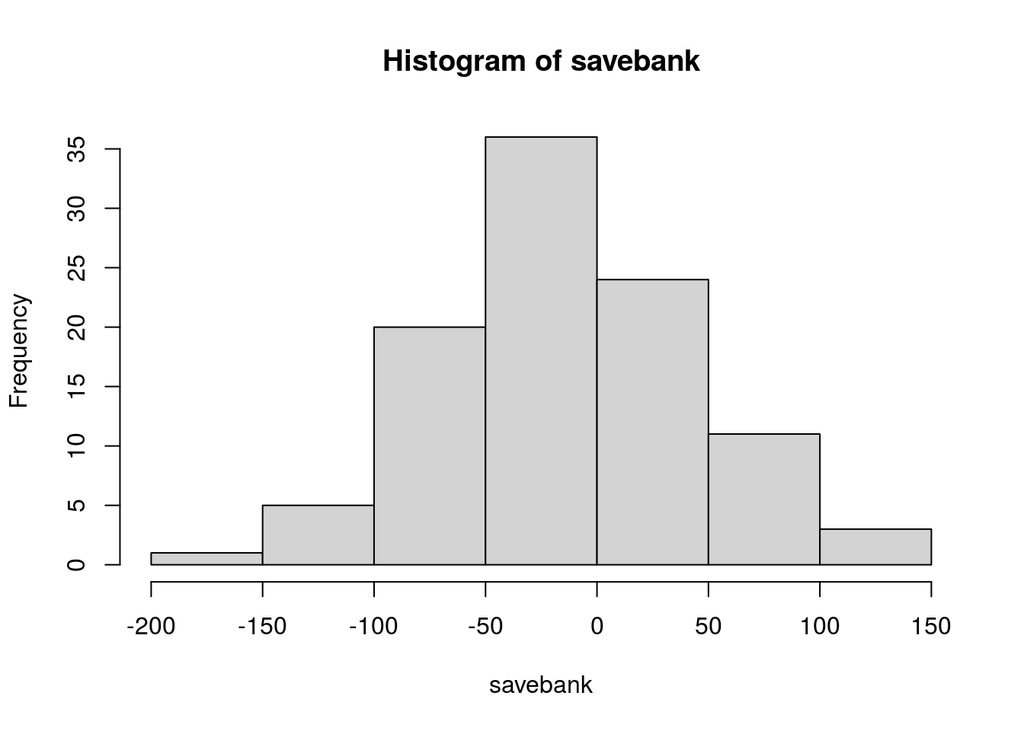

```r
hist(savebank)
```

```r
f=favstats(savebank)
```

The payout that makes this a far bets is 4.5

# 3 What size of class makes the 2:1 bet fair?

```r
bdays=1:365
savebank=vector("numeric")
payout=2
ClassSize=28
for(j in 1:100){
  bank=0
for(i in 1:637){
    classbd=sample(bdays,size=ClassSize,replace=TRUE)
  N=length(unique(classbd))
  if(N==ClassSize)
    bank=bank-payout
  else
    bank=bank+1
}
savebank[j]=bank
}
```

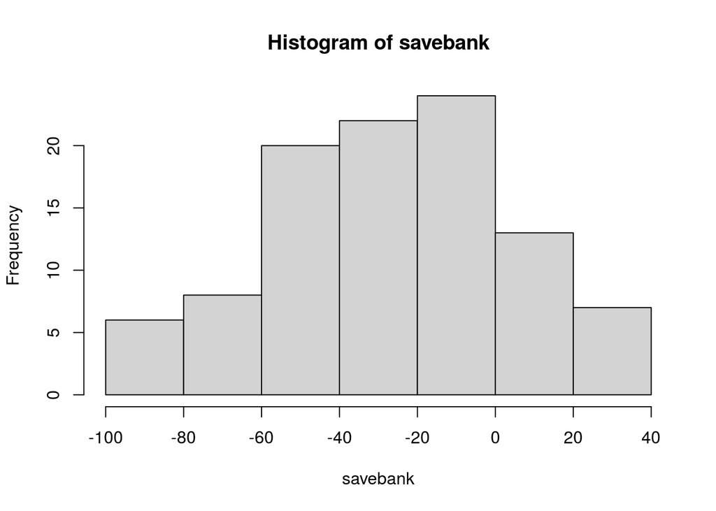

```r
hist(savebank)
```

```r
f=favstats(savebank)
```

# 4 In the class and payoff as described what is a 95% confidence interval for Brownlow’s earnings?

```r
bdays=1:365
savebank=vector("numeric")
payout=2
ClassSize=35
for(j in 1:100){
  bank=0
for(i in 1:637){
    classbd=sample(bdays,size=ClassSize,replace=TRUE)
  N=length(unique(classbd))
  if(N==ClassSize)
    bank=bank-payout
  else
    bank=bank+1
}
savebank[j]=bank
}
```

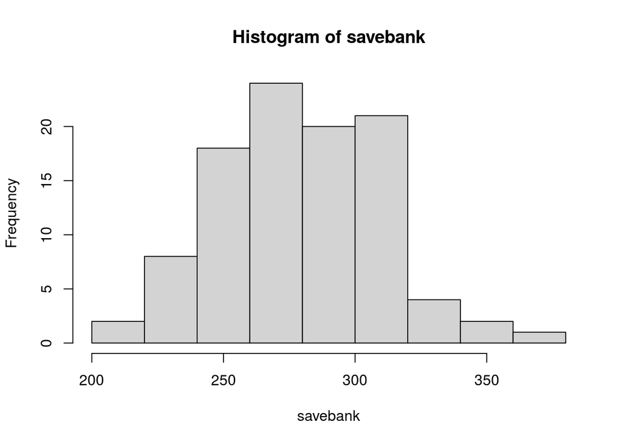

```r
hist(savebank)
```

```r
f=favstats(savebank)
lcl=f$mean-2*f$sd
ucl=f$mean+2*f$sd
print(paste("confidence interval",lcl,ucl))
```

```
## [1] "confidence interval 217.50501538534 343.21498461466"
```

The median profit is 280

# 5 Discussion and Conclusion